# OpenStack OpenAPI specs

# Building up OpenAPI specs for OpenStack APIs

**Date**

2024-05-15

**Author**

Artem Goncharov

# Agenda

- Introduction
- OpenStack API "features"
- Designing OpenAPI for OpenStack
- CodeGenerator
- How OpenAPI specs can be used 🦀

# What is OpenAPI

The OpenAPI Specification, previously known as the Swagger Specification, is a specification for a machine-readable interface definition language for describing, producing, consuming and visualizing web services.

## Version 3.1.0

OpenAPI version 3.1.0, released in 2021, includes JSON schema alignment what allows it to be applied for every API with JSON schema.

# OpenAPI Example

```yaml
openapi: 3.1.0
info:
  version: 1.0.0
  title: Sample API
  description: A sample API to illustrate OpenAPI concepts
paths:
  /list:
    get:
      description: Returns a list of stuff
      request:
        headers:
          ..
        content:
          ..
      responses:
        '200':
          headers:
            ..
          content:
            application/json:
              schema:
                description: Stuff items list
                type: array
                items:
                  type: string
                  description: I am the stuff item
```

# What is OpenAPI good for

- Machine readable API contract
- API documentation consistent with the service code
- Generation of API clients
- Enables API security testing
- Ease API integration into 3rd party frameworks (i.e. API Gateway)
- **Open** *your* **API** (make it consumable)

# OpenStack API

- Every service is exposing their **own individual** API
- **Strongly deviating** despite API-SIG effort
- **Non-declarative**
- **Not directly OpenAPI compatible**

# Dynamic headers

Some services (i.e. Swift) support dynamic (not pre-defined) headers to operate on resource metadata:

```
$> curl -i $publicURL/marktwain/goodbye -X POST -H "X-Object-Meta-Book: GoodbyeColumbus"
```

Danger

OpenAPI requires all supported request and response headers to be described explicitly (name, data type, description)

# [Microversion](https://specs.openstack.org/openstack/api-sig/guidelines/microversion_specification.html)

“API Microversions” allow changes to the API while preserving backward compatibility. The basic idea is that a user has to explicitly ask for their request to be treated with a particular version of the API.

So breaking changes can be added to the API without breaking users who don’t specifically ask for it.

```
$> curl -i $publicURL/volumes -X POST -H "OpenStack-API-Version: volume 3.70" ...
```

Danger

OpenAPI does not support different operations based on the passed headers

# RPC style actions

Few OpenStack services rely on the RPC like actions where operation is routed based on the body.

```
$> curl -i $publicURL/servers/fake_id/action -X POST -d '
    {
        "lock": {"locked_reason": "I don't want to work"}
    }
'
```

# RPC style actions

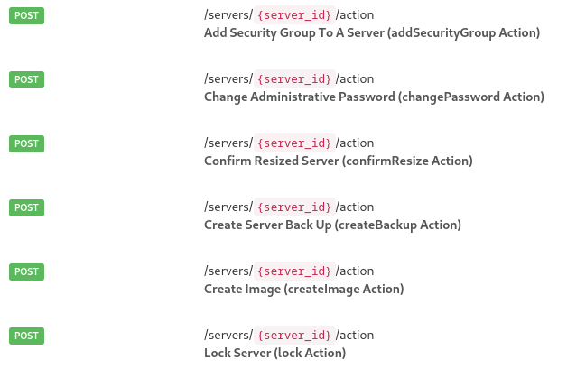

Danger

OpenAPI does not support different operations based on the request body

# So now what?

# “X-” extensions

OpenAPI allows *X-custom* extensions

```yaml
paths:
  /servers:
    put:
      ...
      x-openstack:
        foo: bar
```

# Dynamic headers

Custom OpenAPI parameter serialization based on regex (similar to parameter serialization)

```yaml
paths:
  /foo:
    put:
      ...
      parameters:
        - in: header
          name: X-Account-Meta-*
          schema:
            type: string
          x-openstack:
            style: regex
```

# Microversions

JSON schema `oneOf` with `x-openstack` extension and custom discriminator (polymorphism)

```yaml
components:
  schemas:
    VolumesCreateRequest:
      oneOf:
        - $ref: '#/components/schemas/VolumesCreate_30'
        - $ref: '#/components/schemas/VolumesCreate_313'
        - $ref: '#/components/schemas/VolumesCreate_347'
        - $ref: '#/components/schemas/VolumesCreate_353'
      x-openstack:
        discriminator: microversion
    VolumesCreate_313:
      ...
      x-openstack:
        min-ver: 3.13
        max-ver: 3.46
    ...
```

# RPC style Actions

JSON schema `oneOf` with `x-openstack` extension and custom discriminator

```yaml
components:
  schemas:
    server_actions:
      oneOf:
        - $ref: #/components/schemas/action_foo
        - $ref: #/components/schemas/action_bar
      x-openstack:
        discriminator: action
    action_foo:
      ...
      x-openstack:
        action-name: foo
    action_bar:
      ...
      x-openstack:
        action-name: bar
```

# Actions + microversions

Just a combination of above methods.

```yaml
components:
  schemas:
    server_actions:
      oneOf:
        - $ref: #/components/schemas/action_foo
        - $ref: #/components/schemas/action_bar
      x-openstack:
        discriminator: action
    action_foo:
      oneOf:
        - $ref: #/components/schemas/action_foo_21
        - $ref: #/components/schemas/action_foo_22
      x-openstack:
        action-name: foo
        discriminator: microversion
```

# Constraints

- Strict body definition for certain microversion (no merging or individual parameters)
- Query parameters may be combined for operation marking microversion constraints

```yaml
...
    parameters:
      new_param:
        in: query
        name: foo_by_bar
        description: Filter foos by bars (new in microversion 2.45)
        schema:
          type: string
        x-openstack:
          min-ver: 2.45
```

# And what’s next?

# Let's build OpenAPI specs from service sources

- Inspect source code of services
- Some services have json schema attached to the controllers
- Services use different frameworks (wsgi + routes, pecan, flask, WSME, etc)
- Response descriptions mostly missing

  ==> [CodeGenerator](https://opendev.org/openstack/codegenerator)

# CodeGenerator

- OpenAPI specs by inspecting source code of services
- Rust SDK
- Rust CLI
- Python openstackclient
- Ansible modules
- …

# OpenStack supported services

- Nova (compute)
- Cinder (block-storage)
- Glance (image)
- Neutron (network) + plugins
- Keystone (identity)
- Octavia (load-balancer)
- Placement

# Nova

- ✅ Routes
- ✅ Request data
- ✅ Microversion info
- ✅ Actions
- ❌ Query parameters
- ❌ Response schemas

# Cinder

- ✅ Routes
- ❗ Request data
- ❗ Microversion info
- ✅ Actions
- ❌ Query parameters
- ❌ Response schema

# Glance

- ✅ Routes
- ❗ Request data
- ❗ Query parameters
- ❗ Response schema

# Keystone

- ✅ Routes
- ❗ Request data
- ❌ Query parameters
- ❌ Response schema

# Neutron

- ❗ Routes
- ❗ Request data
- ❗ Query parameters
- ❗ Response schema

# Octavia

- ❗ Routes
- ❗ Request data
- ❌ Query parameters
- ✅ Response schema

# Challenges

- No naming conventions
- Unified behavior for non-standard service functionality is hard
- Used JSON schema libraries have **limited** validation of the schema errors
- OpenAPI validation still **does not** catch all of the JSON schema errors

  => CodeGeneration catches **lot** of schema errors

```json
"type": "object",
"properties": {
  "schema_version": {"name": {"type": "string"}}
}
```

# Small Survey

Who:

- Uses python-openstackclient
- Isn't satisfied with its performance?
- having issues with API and client doing things differently
- likes/doesn't an attempt to normalize OpenStack services
- wants a small binary cli to skip dependency hell
- frustrated with malfunctioning automation and missing bypass capabilities

# Rust Tooling 🦀💖

https://github.com/gtema/openstack

- SDK
  - sync
  - async
- CLI

```
$> osc --os-cloud devstack compute server list

+------------------+-------+---------+
| id               | name  | status  |
+------------------+-------+---------+
| aaed1db9-***-*** | s**** | ACTIVE  |
| c080769c-***-*** | w**** | ACTIVE  |
| 28aef686-***-*** | y**** | ACTIVE  |
| 3c178e63-***-*** | h**** | ACTIVE  |
| b62f9988-***-*** | 3**** | ACTIVE  |
| 1b129bad-***-*** | s**** | SHUTOFF |
+------------------+-------+---------+
```

# Benchmark

- Scalability
- Sustainability
- Efficiency

| Test | OSC (python) | OSC (Rust) |
| --- | --- | --- |
| catalog list | 1.54s | 68ms |
| flavor list | 2.6s | 830ms |
| server list (empty) | 1.8s | 210ms |
| server list (10 entries) | 4.0s | 709ms |
| image list | 2.4s | 560ms |
| network list | 1.8s | 330ms |
| volume list | 1.9s | 270ms |
| container list | 1.3s | 370ms |
| object list (3200 files) | 2.4s | 1.0s |
| object list (10000 files) | 3.8s | 1.7s |

# Rust tooling

- 10,000loc maintains 500,000+ loc Rust tooling
- Unix philosophy: "do one thing well"
- Awesome performance
- Compiled binary
- Unavoidable consistency (matching to the API functionality)
- ...
- Private project, [sponsoring](https://github.com/sponsors/gtema) is very 🥰

# Next Steps

- Improve OpenStack pipeline for handling specs
- Improve OpenStack services to add missing schema
- Continue extending generator targets (i.e. TUI, GopherCloud, OpenTofu)
- Central api gateway using OpenAPI specs
  - improved central logging
  - central API metrics capture
  - throttling, Anti-DDoS, etc
- Security scanning of the APIs
- Replace OpenStack API-Ref (documentation)

# Thank you

## Links:

- https://opendev.org/openstack/codegenerator/
- https://github.com/gtema/openstack
- https://gtema.github.io/openstack-openapi/